# Segundo Trabajo Practico - Aprendizaje Supervisado y No Supervisado

Alex Gabriel Cerutti 78708

4 de noviembre de 2022

## DataSet

Game of Thrones (Juego de Tronos) es un exitoso programa de television de fantasia basado en la igualmente famosa serie de libros “A Song of Fire and Ice (Canción de Hielo y Fuego)” de George RR Martin. El programa es conocido por su trama politica enormemente complicada, gran cantidad de personajes y sus frecuentes muertes de personajes. En este trabajo Práctico se analizará archivo characterDeaths.csv que contiene los datos respecto a las muertes de los personajes de los diferentes libros, cabe aclarar que incluye aquellos personajes que aun se encuentran vivos.

### **Variables**

- **Name** : Nombre del personaje
- **Allegiances** : Casa a la que se encuentra aliado el personaje
- **Death.Year** : Anio de fallecimmiento (en caso que no contenga datos, indica que el personaje está vivo)
- **Book.of.Death** : Libro en el que fallecio
- **Death.Chapter** : Capitulo del libro en el que fallecio
- **Book.Intro.Chapter**: Capitulo del libro en el que aparece por primera vez
- **Gender** : Genero del personaje (0-Femenino ; 1-Masculino)
- **Nobility** : Indica si pertenece a familia noble (1) o no(0)
- **GoT** : Indica si el personaje aparece o no en el libro 1 (*Game of Thrones*)
- **CoK** : Indica si el personaje aparece o no en el libro 2 (*Clash of Kings*)
- **SoS** : Indica si el personaje aparece o no en el libro 3 (*Storm of Swords*)
- **FfC** : Indica si el personaje aparece o no en el libro 4 (*Feast of Crows*)
- **DwD** : Indica si el personaje aparece o no en el libro 5 (*Dance with Dragons*)

## Ejercicio N 1

Cargar el dataset denominado characterDeaths2. NOTA: Los datos se encuentran separados por ;

```r
wd = getwd()
cd2 = read.csv('C:/characterDeaths2.csv', header = TRUE, sep=";", na.strings = c(''))
```

## Ejercicio N 2

Realizar una limpieza de datos en caso de que corresponda. Justifique su accion

```r
na_count <- sapply(cd2, function(y) sum(length(which(is.na(y)))))
na_count <- data.frame(na_count)
na_count
```

```
##                    na_count
## Name                      0
## Death.Year              609
## Book.of.Death           609
## Death.Chapter           609
## Book.Intro.Chapter        0
## Gender                    0
## Nobility                  0
## GoT                       0
## CoK                       0
## SoS                       0
## FfC                       0
## DwD                       0
```

Se puede observar que existen 3 columnas con valores NA, siguiendo el criterio del anterior trabajo practico (si las columnas de Death.Year, Book.of.Death y Death.Year son NA simultaneamente, se interpreta que el personaje esta vivo), se procederá a realizar la limpieza

```r
cd2$Death.Year[is.na(cd2$Death.Year) & is.na(cd2$Book.of.Death) & is.na(cd2$Death.Chapter)] <- "Alive"
cd2$Book.of.Death[cd2$Death.Year == "Alive" & is.na(cd2$Book.of.Death) & is.na(cd2$Death.Chapter)] <- "Alive"
cd2$Death.Chapter[cd2$Death.Year == "Alive" & cd2$Book.of.Death == "Alive" & is.na(cd2$Death.Chapter)] <- "Alive"

na_count <- sapply(cd2, function(y) sum(length(which(is.na(y)))))
na_count <- data.frame(na_count)
na_count
```

```
##                    na_count
## Name                      0
## Death.Year                0
## Book.of.Death             0
## Death.Chapter             0
## Book.Intro.Chapter        0
## Gender                    0
## Nobility                  0
## GoT                       0
## CoK                       0
## SoS                       0
## FfC                       0
## DwD                       0
```

Los datos ahora estan limpios

## Ejercicio 3

Genere una nueva columna que indique si el personaje esta vivo (1) o no (0). En caso que la nueva columna no sea de tipo factor, conviertala

```r
cd2$Is.Alive[cd2$Death.Year=="Alive" | cd2$Book.of.Death=="Alive" | cd2$Death.Chapter=="Alive"] <- 1.0
cd2$Is.Alive[cd2$Death.Year!="Alive" & cd2$Book.of.Death!="Alive" & cd2$Death.Chapter!="Alive"] <- 0
str(cd2)
```

```
## 'data.frame':    917 obs. of  13 variables:
##  $ Name              : chr  "Addam Marbrand" "Aegon Frey (Jinglebell)" "Aegon Targaryen" "Adrack Humble" ...
##  $ Death.Year        : chr  "Alive" "299" "Alive" "300" ...
##  $ Book.of.Death     : chr  "Alive" "3" "Alive" "5" ...
##  $ Death.Chapter     : chr  "Alive" "51" "Alive" "20" ...
##  $ Book.Intro.Chapter: int  56 49 5 20 21 34 21 59 11 6 ...
##  $ Gender            : int  1 1 1 1 1 1 1 0 1 1 ...
##  $ Nobility          : int  1 1 1 1 1 1 1 1 1 0 ...
##  $ GoT               : int  1 0 0 0 0 0 1 1 0 0 ...
##  $ CoK               : int  1 0 0 0 0 1 0 1 1 0 ...
##  $ SoS               : int  1 1 0 0 1 1 1 1 0 1 ...
##  $ FfC               : int  1 0 0 0 0 0 1 0 1 0 ...
##  $ DwD               : int  0 0 1 1 0 0 0 1 0 0 ...
##  $ Is.Alive          : num  1 0 1 0 1 1 0 0 1 1 ...
```

Como la columna se genero como un tipo numeric, se convertira a factor

```r
cd2$Is.Alive <- as.factor(cd2$Is.Alive)
str(cd2)
```

```
## 'data.frame':    917 obs. of  13 variables:
##  $ Name              : chr  "Addam Marbrand" "Aegon Frey (Jinglebell)" "Aegon Targaryen" "Adrack Humble" ...
##  $ Death.Year        : chr  "Alive" "299" "Alive" "300" ...
##  $ Book.of.Death     : chr  "Alive" "3" "Alive" "5" ...
##  $ Death.Chapter     : chr  "Alive" "51" "Alive" "20" ...
##  $ Book.Intro.Chapter: int  56 49 5 20 21 34 21 59 11 6 ...
##  $ Gender            : int  1 1 1 1 1 1 1 0 1 1 ...
##  $ Nobility          : int  1 1 1 1 1 1 1 1 1 0 ...
##  $ GoT               : int  1 0 0 0 0 0 1 1 0 0 ...
##  $ CoK               : int  1 0 0 0 0 1 0 1 1 0 ...
##  $ SoS               : int  1 1 0 0 1 1 1 1 0 1 ...
##  $ FfC               : int  1 0 0 0 0 0 1 0 1 0 ...
##  $ DwD               : int  0 0 1 1 0 0 0 1 0 0 ...
##  $ Is.Alive          : Factor w/ 2 levels "0","1": 2 1 2 1 2 2 1 1 2 2 ...
```

## Ejercicio N 4

Considerando que la variable a predecir es la creada en el punto anterior, responda:

1. ?Puede utilizar regresion logistica para predecir dicha variable? Justifique su respuesta.
2. En caso de respuesta afirmativa al punto a:

+. Cuales considera variables independendientes o predictoras? Porque?

+. Aplique el metodo.

+. Pruebe el modelo obtenido, indicando el porcentaje de error

```r
cd3 <- cd2[,!names(cd2) %in% c("Name","Death.Year","Book.of.Death","Death.Chapter")]
library(caTools)
set.seed(1000)
split = sample.split(cd3$Is.Alive,SplitRatio = 0.65) #tomo 65% de los datos para training dataset
train = subset(cd3,split==TRUE)
test = subset(cd3,split==FALSE)
model = glm(Is.Alive ~ . ,data = train,family = binomial)
summary(model)
```

```
##
## Call:
## glm(formula = Is.Alive ~ ., family = binomial, data = train)
##
## Coefficients:
##                     Estimate Std. Error z value Pr(>|z|)
## (Intercept)         0.124846   0.343294   0.364  0.71610
## Book.Intro.Chapter  0.008363   0.005057   1.654  0.09818 .
## Gender             -0.487445   0.266649  -1.828  0.06754 .
## Nobility            0.623340   0.195027   3.196  0.00139 **
## GoT                -0.307867   0.214120  -1.438  0.15048
## CoK                -0.258426   0.203925  -1.267  0.20506
## SoS                -0.112294   0.197742  -0.568  0.57012
## FfC                 1.764283   0.275083   6.414 1.42e-10 ***
## DwD                 0.987522   0.227929   4.333 1.47e-05 ***
## ---
## Signif. codes:  0 '***' 0.001 '**' 0.01 '*' 0.05 '.' 0.1 ' ' 1
##
## (Dispersion parameter for binomial family taken to be 1)
##
##     Null deviance: 760.56  on 595  degrees of freedom
## Residual deviance: 659.63  on 587  degrees of freedom
## AIC: 677.63
##
## Number of Fisher Scoring iterations: 4
```

```r
predictTest = predict(model, type = "response",newdata = test)
predictTest <- ifelse(predictTest > 0.5,1,0)
ErrorClasif <- mean(predictTest != test$Is.Alive)
ErrorClasif
```

```
## [1] 0.3115265
```

```r
print(paste('Accuracy',1-ErrorClasif))
```

```
## [1] "Accuracy 0.688473520249221"
```

```r
print(paste('Accuracy',mean(predictTest == test$Is.Alive)))
```

```
## [1] "Accuracy 0.688473520249221"
```

Se puede observar que el porcentaje de precision es de 68,84%, por lo que el porcentaje de error es del 31,15%

## Ejercicio N 5

Indique si Daenerys Targaryen vivira o morira en los siguientes libros, basandose en su prediccion

```r
characterTest <- cd2[cd2$Name == "Daenerys Targaryen",]
characterTest <- characterTest[,!names(cd2) %in% c("Name","Death.Year","Book.of.Death","Death.Chapter")]
characterPredictTest = predict(model, type = "response",newdata = characterTest)
characterPredictTest
```

```
##       163
## 0.7469119
```

```r
ifelse(characterPredictTest > 0.5,"Vivira","Morira")
```

```
##      163
## "Vivira"
```

La prediccion para este personaje indica que vivira en los siguientes libros, con una probabilidad del 74,69%

## Ejercicio N 6

Generar un arbol de decision con ctree. Grafique el arbol generado. Luego, probar el modelo, indicando el error encontrado.

```r
library(party)
set.seed(1000)
split <- sample.split(cd3$Is.Alive,SplitRatio = 0.65) #tomo 65% de los datos para training dataset
train <- subset(cd3,split==TRUE)
test <- subset(cd3,split==FALSE)
modelC <- ctree(Is.Alive ~ . ,data = train)
summary(modelC)
```

```
##     Length      Class       Mode
##          1 BinaryTree         S4
```

```r
print(modelC)
```

```
##
##   Conditional inference tree with 4 terminal nodes
##
## Response:  Is.Alive
## Inputs:  Book.Intro.Chapter, Gender, Nobility, GoT, CoK, SoS, FfC, DwD
## Number of observations:  596
##
## 1) FfC <= 0; criterion = 1, statistic = 49.635
##   2) DwD <= 0; criterion = 1, statistic = 27.444
##     3)*  weights = 290
##   2) DwD > 0
##     4)*  weights = 141
## 1) FfC > 0
##   5) Nobility <= 0; criterion = 0.985, statistic = 9.683
##     6)*  weights = 67
##   5) Nobility > 0
##     7)*  weights = 98
```

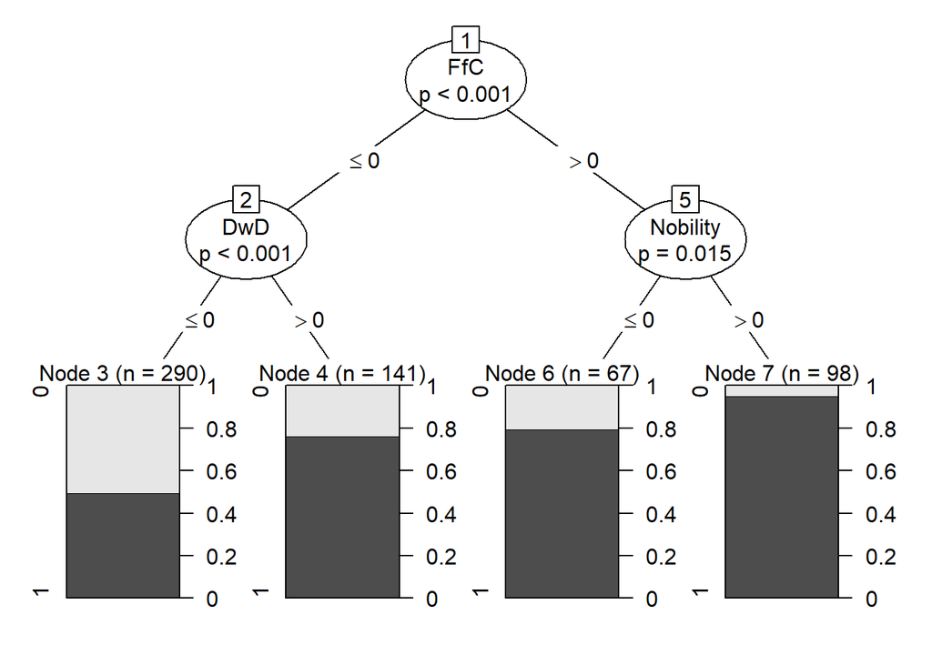

```r
plot(modelC)
```

```r
predictTest <- predict(modelC, newdata = test)
table(predictTest, test$Is.Alive)
```

```
##
## predictTest   0   1
##           0  82  85
##           1  26 128
```

Probando con los datos del test se obtiene la siguiente la tabla

```r
predictTest <- predict(modelC, newdata = test)
table(predictTest, test$Is.Alive)
```

```
##
## predictTest   0   1
##           0  82  85
##           1  26 128
```

La tabla muestra que hay 111 desaciertos, sobre un total de 321 predicciones, dividiendo estos valores se obtiene que el error de prediccion es del 34,57%

## Ejercicio N 7

Aplique la funcion randomforest. Probar el modelo, indicando el error encontrado.

```r
library(randomForest)
set.seed(1000)
split <- sample.split(cd3$Is.Alive,SplitRatio = 0.65) #tomo 65% de los datos para training dataset
train <- subset(cd3,split==TRUE)
test <- subset(cd3,split==FALSE)
modelF <- randomForest(Is.Alive ~ . ,data = train, ntree = 100, proximity=TRUE)
summary(modelF)
```

```
##                 Length Class  Mode
## call                 5 -none- call
## type                 1 -none- character
## predicted          596 factor numeric
## err.rate           300 -none- numeric
## confusion            6 -none- numeric
## votes             1192 matrix numeric
## oob.times          596 -none- numeric
## classes              2 -none- character
## importance           8 -none- numeric
## importanceSD         0 -none- NULL
## localImportance      0 -none- NULL
## proximity       355216 -none- numeric
## ntree                1 -none- numeric
## mtry                 1 -none- numeric
## forest              14 -none- list
## y                  596 factor numeric
## test                 0 -none- NULL
## inbag                0 -none- NULL
## terms                3 terms  call
```

```r
print(modelF)
```

```
##
## Call:
##  randomForest(formula = Is.Alive ~ ., data = train, ntree = 100,      proximity = TRUE)
##                Type of random forest: classification
##                      Number of trees: 100
## No. of variables tried at each split: 2
##
##         OOB estimate of  error rate: 32.05%
## Confusion matrix:
##    0   1 class.error
## 0 72 128   0.6400000
## 1 63 333   0.1590909
```

```r
predictTest <- predict(modelF, newdata = test)
table(predictTest, test$Is.Alive)
```

[output not shown]

Se puede ver que existe un error de clasificacion del 64% para los personajes muertos, y un error del 15,9% para los personajes vivos

Y probando el modelo con los datos de test, se obtiene la siguiente tabla

```r
predictTest <- predict(modelF, newdata = test)
table(predictTest, test$Is.Alive)
```

```
##
## predictTest   0   1
##           0  54  33
##           1  54 180
```

## Ejercicio N 8

Aplicar algun algoritmo de clustering que determine automaticamente la cantidad de grupos a clusters. ?Cuantos grupos se detectaron?

Para este proposito se puede utilizar pamK

```r
library(fpc)
cd4 <- cd3
cd4$Is.Alive <- NULL
pamk.result <- pamk(cd4)
pamk.result$nc
```

```
## [1] 2
```

```r
table(pamk.result$pamobject$clustering)
```

```
##
##   1   2
## 421 496
```

En donde se detectaron que existen 2 grupos